# Improving Visualizations

Martin Sloley

Lately I have been working a lot on improving my technical skills, but I also need to be better about some of my soft skills, and in particular, my ability to communicate visually with data. In an effort to improve this ability, I am taking data from older projects and improving old visualizations, as well as adding new ones.

# 1 Traffic in Seattle

We may as well start with the inspiration for this project, the [Scientific American “Baby Spike” visualization](https://www.visualcinnamon.com/2017/10/creating-baby-births-visual/). While reading Bremer’s linked blog post, I realized that I had done a project that also contained cyclical time series information that may benefit from a visualization like this. We see the result of my attempt below.

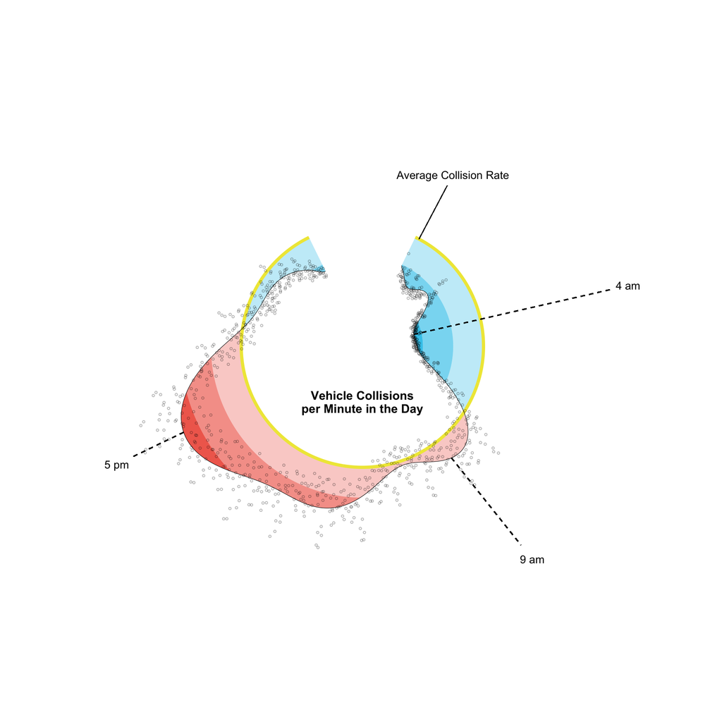

Just like Bremer’s visualization, each color band in this plot denotes a normalized distance from the mean, specifically one-half of one standard deviation. I opted against the y-axis (or $r$ axis in polar coordinates) ticks, as they are labeled as standardized z-scores and I thought they would be misleading. I think I also used a different aggregation method to indicate event frequency than Bremer, so my y-axis labels would have been misleading either way. However, because of the normalization, my plot can be interpreted the same way as Bremer’s with respect to frequency of measured events.

I also actually kind of like the same plot when it’s unwrapped:

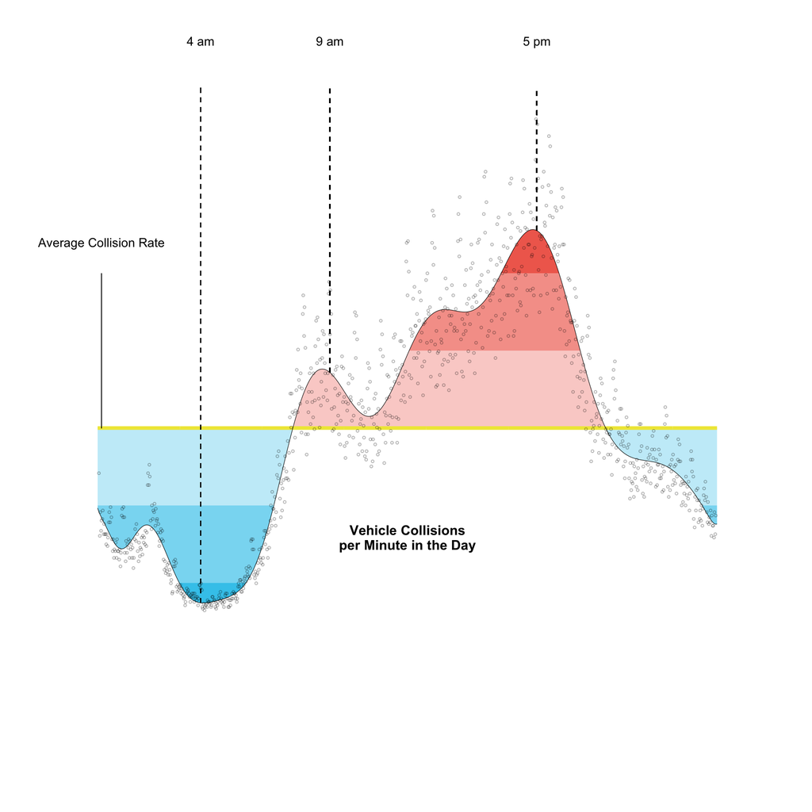